# Prediction of Exercise Quality from Personal Wearable Accelerometer Data

John Stevenson

January 31, 2016

# Abstract

A training dataset of wearable accelerometer data is explored. Relevant variables for the prediction of the classe variable (exercise method) are identified and a prediction model is selected and trained. The performance model on the training set is presented and predictions of the classe classification for the test set are given.

# Data

The [training data](https://d396qusza40orc.cloudfront.net/predmachlearn/pml-training.csv) and test data are downloaded and examined. This [reference](http://groupware.les.inf.puc-rio.br/work.jsf?p1=10335) must be provided when referencing these data.

```r
library(caret, quietly=TRUE)
setwd("C:/Users/jackc_000/Desktop/r_code")
trn <-read.csv("pml-training.csv",na.strings=c('NA','#DIV/0!'))
str(trn)
```

```
## 'data.frame':    19622 obs. of  160 variables:
##  $ X                       : int  1 2 3 4 5 6 7 8 9 10 ...
##  $ user_name               : Factor w/ 6 levels "adelmo","carlitos",..: 2 2 2 2 2 2 2 2 2 2 ...
##  $ raw_timestamp_part_1    : int  1323084231 1323084231 1323084231 1323084232 1323084232 1323084232 1323084232 1323084232 1323084232 1323084232 ...
##  $ raw_timestamp_part_2    : int  788290 808298 820366 120339 196328 304277 368296 440390 484323 484434 ...
##  $ cvtd_timestamp          : Factor w/ 20 levels "02/12/2011 13:32",..: 9 9 9 9 9 9 9 9 9 9 ...
##  $ new_window              : Factor w/ 2 levels "no","yes": 1 1 1 1 1 1 1 1 1 1 ...
##  $ num_window              : int  11 11 11 12 12 12 12 12 12 12 ...
##  $ roll_belt               : num  1.41 1.41 1.42 1.48 1.48 1.45 1.42 1.42 1.43 1.45 ...
##  $ pitch_belt              : num  8.07 8.07 8.07 8.05 8.07 8.06 8.09 8.13 8.16 8.17 ...
##  $ yaw_belt                : num  -94.4 -94.4 -94.4 -94.4 -94.4 -94.4 -94.4 -94.4 -94.4 -94.4 ...
##  $ total_accel_belt        : int  3 3 3 3 3 3 3 3 3 3 ...
##  $ kurtosis_roll_belt      : num  NA NA NA NA NA NA NA NA NA NA ...
##  $ kurtosis_picth_belt     : num  NA NA NA NA NA NA NA NA NA NA ...
##  $ kurtosis_yaw_belt       : logi  NA NA NA NA NA NA ...
```

[output cut: 86 more lines]

There are a large number of measurements that are NA or very sparse. They are removed. Also, the first 7 columns are either factors or descriptive rather than measurements and are also removed. To check for a possible need for scaling, a histogram of classe is examined,

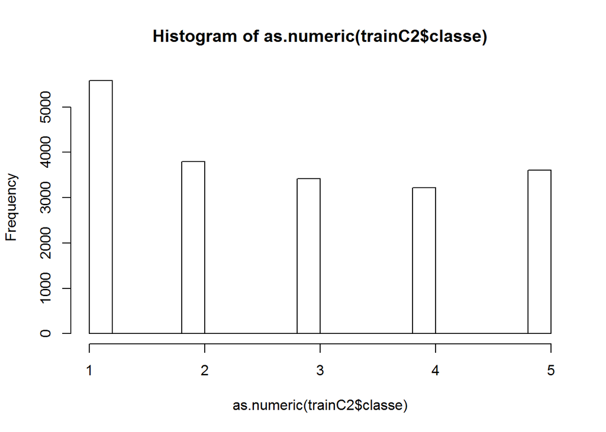

```r
trainC <- trn[,!apply(trn,2,function(x) any(is.na(x)))]
trainC2<-trainC[,c(8:ncol(trainC))]
hist(as.numeric(trainC2$classe))
```

Training and cross-validation data sets are created.

```r
trainI <- createDataPartition(y=trainC2$classe,p=0.8,list=FALSE)
trainData<- trainC2[trainI,]
valData<-trainC[-trainI,]
dim(trainData);dim(valData)
```

```
## [1] 15699    53
```

```
## [1] 3923   60
```

# Prediction Modelling and Performance

A Random Forest Model is chosen and calibrated. The predictions of this model for the validation data are generated. The performance of the model on the validation data including the out of sample error is given through the confusion matrix.

```r
 model<-train(classe ~.,data=trainData,method='rf',trControl=trainControl(method="cv",number=4,allowParallel=TRUE,verboseIter=TRUE))
pred<-predict(model,valData)
cm<-confusionMatrix(pred,valData$classe)
cm
```

```
## Confusion Matrix and Statistics
##
##           Reference
## Prediction    A    B    C    D    E
##          A 1116    4    0    0    0
##          B    0  755    6    0    0
##          C    0    0  677    7    0
##          D    0    0    1  636    0
##          E    0    0    0    0  721
##
## Overall Statistics
##
##                Accuracy : 0.9954
##                  95% CI : (0.9928, 0.9973)
##     No Information Rate : 0.2845
##     P-Value [Acc > NIR] : < 2.2e-16
##
##                   Kappa : 0.9942
##  Mcnemar's Test P-Value : NA
##
## Statistics by Class:
##
##                      Class: A Class: B Class: C Class: D Class: E
## Sensitivity            1.0000   0.9947   0.9898   0.9891   1.0000
## Specificity            0.9986   0.9981   0.9978   0.9997   1.0000
## Pos Pred Value         0.9964   0.9921   0.9898   0.9984   1.0000
## Neg Pred Value         1.0000   0.9987   0.9978   0.9979   1.0000
## Prevalence             0.2845   0.1935   0.1744   0.1639   0.1838
## Detection Rate         0.2845   0.1925   0.1726   0.1621   0.1838
## Detection Prevalence   0.2855   0.1940   0.1744   0.1624   0.1838
## Balanced Accuracy      0.9993   0.9964   0.9938   0.9944   1.0000
```

# Predictions on the test data

The test data is loaded and the predictions of the classe for each row are presented.

```r
setwd("C:/Users/jackc_000/Desktop/r_code")
test<-read.csv("pml-testing.csv",na.strings=c('NA','#DIV/0!'))
predict(model,test)
```

```
##  [1] B A B A A E D B A A B C B A E E A B B B
## Levels: A B C D E
```